# Eduardo Demetrio

Estatistica nao-parametrica

2025-04-13

# Como será feito.

- Vou utilizar o R para resolução dos cálculos com intuito de ter a prática e finalizando com explicações complementares no rmarkdown.
- Como iremos entregar esse trabalho, tudo estara unificado no rmarkdown

# Repositório.

- Teremos também um repositório com todo desenvolvimento do trabalho no GitHub. [🔗 Repositório no GitHub](https://github.com/EduardoDemetrio/Estat_nao_parametrica.git)

# Trabalho - Questão 1

1.*Seja X ∼ Bernoulli(1/2) e considere todas as possíveis amostras aleatórias de tamanho n = 4. Calcule Xn e Sn2 para cada uma das dezesseis amostras. Encontre a função de probabilidade de Xn e Sn2*

**Resposta:**

Iniciei criando a amoastra conforme foi solicitado pelo exercicio, calculando também a média e variancia da amostra.

```r
amostras <- expand.grid(rep(list(c(0, 1)), 4)); amostras
```

| Var1 | Var2 | Var3 | Var4 |
| --- | --- | --- | --- |
| 0 | 0 | 0 | 0 |
| 1 | 0 | 0 | 0 |
| 0 | 1 | 0 | 0 |
| 1 | 1 | 0 | 0 |
| 0 | 0 | 1 | 0 |
| 1 | 0 | 1 | 0 |
| 0 | 1 | 1 | 0 |
| 1 | 1 | 1 | 0 |
| 0 | 0 | 0 | 1 |
| 1 | 0 | 0 | 1 |

[output cut: 6 more lines]

```r
colnames(amostras) <- paste0("X", 1:4) # Renomear colunas para clareza
media <- apply(amostras, 1, mean)
variancia <- apply(amostras, 1, function(x) var(x))
resultado <- data.frame(amostras, media, variancia); resultado
```

| X1 | X2 | X3 | X4 | media | variancia |
| --- | --- | --- | --- | --- | --- |
| 0 | 0 | 0 | 0 | 0.00 | 0.0000000 |
| 1 | 0 | 0 | 0 | 0.25 | 0.2500000 |
| 0 | 1 | 0 | 0 | 0.25 | 0.2500000 |
| 1 | 1 | 0 | 0 | 0.50 | 0.3333333 |
| 0 | 0 | 1 | 0 | 0.25 | 0.2500000 |
| 1 | 0 | 1 | 0 | 0.50 | 0.3333333 |
| 0 | 1 | 1 | 0 | 0.50 | 0.3333333 |
| 1 | 1 | 1 | 0 | 0.75 | 0.2500000 |
| 0 | 0 | 0 | 1 | 0.25 | 0.2500000 |
| 1 | 0 | 0 | 1 | 0.50 | 0.3333333 |

[output cut: 6 more lines]

E fiz o cálculo de Xn e do Sn2

```r
tabela_media <- table(resultado$media) / nrow(resultado)
media_df <- data.frame(
  Valor_Xn = names(tabela_media),
  Probabilidade = as.numeric(tabela_media)
); media_df
```

| Valor_Xn | Probabilidade |
| --- | --- |
| 0 | 0.0625 |
| 0.25 | 0.2500 |
| 0.5 | 0.3750 |
| 0.75 | 0.2500 |
| 1 | 0.0625 |

```r
tabela_variancia <- table(round(resultado$variancia, 3)) / nrow(resultado)
variancia_df <- data.frame(
  Valor_Sn2 = names(tabela_variancia),
  Probabilidade = as.numeric(tabela_variancia)
)
variancia_df$Valor_Sn2 <- ifelse(variancia_df$Valor_Sn2 == "0.25", "1/4",
                                ifelse(variancia_df$Valor_Sn2 == '0.333', "1/3",
                                        variancia_df$Valor_Sn2)); variancia_df
```

| Valor_Sn2 | Probabilidade |
| --- | --- |
| 0 | 0.125 |
| 1/4 | 0.500 |
| 1/3 | 0.375 |

# Trabalho - Questão 2

- 1. *Escreva uma função R para encontrar estimativas de ∆(F,G), considerando valores diversos de tamanhos de cada amostra.*

Função criada no R

```r
phi <- function(X1, X2, Y1, Y2) {
  if (max(X1, X2) < min(Y1, Y2) || max(Y1, Y2) < min(X1, X2)) {
    return(1)
  } else {
    return(0)
  }
}

# Função para estimar delta
delta_est <- function(X, Y) {
  m <- length(X)
  n <- length(Y)
  u_sum <- 0

  for (i1 in 1:(m - 1)) {
    for (i2 in (i1 + 1):m) {
      for (k1 in 1:(n - 1)) {
        for (k2 in (k1 + 1):n) {
          u_sum <- u_sum + phi(X[i1], X[i2], Y[k1], Y[k2])
        }
      }
    }
  }

  u_stat <- (1 / (choose(m, 2) * choose(n, 2))) * u_sum
  delta <- (1 / 2) * u_stat - 1 / 6
  return(delta)
}
```

- 2. *Gere amostras de tamanho 50, 100 e 150 das distribuições (i) Normal padrão, (ii) Cauchy padrão e (iii) t-Student(4). Considere estas como possíveis distribuições de referência
- 3. Calcule as estimativas de ∆( F, G) para cada amostra das distribuicoes de referencia F obtidas no item (b) e a amostra da distribuicoes desconhecida G, obtida no arquivo de dados anexo 𝐹.*

E da maneira que foi solicitado foi feito sua distribuição com as amostras de tamanhos solicitado. E foi calculado com a amostra do arquivo G, fornecido pelo professor para o calculo.

```
*Foi carregado como vetor, os valores lidos nos dados fornecidos pelo professor, para melhorar a visualização no rmarkdown, porém podemos alterar o G para utilizar o CSV*
```

```r
# (b) Gerar amostras de referência F
set.seed(123)

tamanhos <- c(50, 100, 150)

G <- c(
  1.20993792, 2.70931325, -2.23045222, -1.31404547, 1.64363149, -0.10981814,
 -1.40912537, 0.55417387, 2.29231165, 1.39674384, 7.52856526, -0.62024631,
  0.89589753, 3.15583909, -0.08941819, 0.41208316, -2.30509805, -1.34179543,
 -3.39419760, -0.01094489, 0.14339852, -0.03119816, -1.02993491, 4.96612469,
  0.52148086, 6.17127341, 0.66285102, 4.25641863, -0.63118788, 0.15960493,
  1.63625792, -0.53992801, 0.12696711, -0.76629781, -0.12113516, -1.80659842,
  0.02739343, 9.26852193, -1.23531622, 0.08876878, -0.52753330, -1.02278015,
  1.09228552, -1.02601047, -1.67188166, 0.60013615, -1.69435036, -0.22235898,
 -0.50567413, -0.82160856, -1.51361057, -3.38756877, 3.18889321, 0.42659102,
 -0.63389477, -1.23447044, -0.78414318, 0.05760501, 0.61059967, -3.12271995,
  0.25889669, -1.31188617, -4.93261392, 1.23073774, 2.83494961, -1.65830324,
  0.55870567, 0.35471467, -9.48258386, 0.33606778, 0.30220835, -2.12640606,
 -4.90304950, 1.42796624, 1.10600869, -2.26194018, -0.58818937, 0.16275304,
 -0.02408485, 0.06950054, 0.63390953, 1.67515978, -0.49030125, 0.65400424,
 -0.74907037, -0.47497641, 11.34683047, -1.99031097, 1.63233147, 9.36457128,
 -0.18293344, 0.97189985, 0.07066822, -0.10381749, 1.06521944, -1.90154916,
  0.24134585, -0.09691798, -0.26165353, -0.43964692
)

# Lista para armazenar resultados
resultados <- list()

for (n in tamanhos) {
  X_normal <- rnorm(n)
  X_cauchy <- rcauchy(n)
  X_t4 <- rt(n, df = 4)

  delta_normal <- delta_est(X_normal, G)
  delta_cauchy <- delta_est(X_cauchy, G)
  delta_t <- delta_est(X_t4, G)

  resultados[[paste0("n=", n)]] <- data.frame(
    Distribuicao = c("Normal", "Cauchy", "t-Student(4)"),
    Delta = c(delta_normal, delta_cauchy, delta_t)
  )
}
for (nome in names(resultados)) {
  cat("\n--- Resultados para", nome, "---\n")
  print(resultados[[nome]])
}
```

```
##
## --- Resultados para n=50 ---
##   Distribuicao        Delta
## 1       Normal  0.001144836
## 2       Cauchy -0.003845723
## 3 t-Student(4) -0.003234467
##
## --- Resultados para n=100 ---
##   Distribuicao        Delta
## 1       Normal  0.002379798
## 2       Cauchy -0.002624242
## 3 t-Student(4)  0.001749495
##
## --- Resultados para n=150 ---
##   Distribuicao        Delta
## 1       Normal  0.002312539
## 2       Cauchy -0.001832102
## 3 t-Student(4) -0.001531901
```

- 4. *Segundo seus calculos, qual é a distribuicao desconhecida G?*

# Trabalho - Questão 3

- 1. *Encontre o estimador não viciado de minima variacia de E(XY)?*

Como X e Y são independentes, um estimador não viciado de E(XY) é o produto das médias amostrais

```r
est_esperanca_XY <- function(X, Y) {
  mean(X) * mean(Y)
}
```

- 2. *Encontre o estimador não viciado de minima variacia da VAR(X+ Y)?*

Este é o estimador não viciado de mínima variância

```r
est_var_XmaisY <- function(X, Y) {
  var(X) + var(Y)  # var() em R já retorna o estimador não-viciado
}
```

E com esses cálculos vamos fazer alguns testes com a G e com dados aletórios

```r
# Com a G
set.seed(123)  # Reprodutibilidade
X <- rnorm(n)  # Referência F ~ Normal(0, 1)
Y <- G
esperanca_xy <- est_esperanca_XY(X, Y) ; esperanca_xy
```

```
## [1] -0.005108051
```

```r
variancia_xmaisy <- est_var_XmaisY(X, Y) ; variancia_xmaisy
```

```
## [1] 8.324282
```

```r
# Com amostras aleatórias
set.seed(123)
X <- rnorm(30)
Y <- runif(40)
esperanca_xy <- est_esperanca_XY(X, Y)
variancia_xmaisy <- est_var_XmaisY(X, Y)
```

# Trabalho - Questão 4

4. -a. *Obtenção de Novas Amostras a partir da Densidade Kernel Estimada* Considerando a densidade kernel estimada como a função de densidade de uma amostra e obter novas amostras a partir dela. O documento descreve um algoritmo para gerar amostras de tamanho N a partir da densidade kernel estimada dos dados em `phipsi`.

   O algoritmo é o seguinte:
   1. Escolha `i` aleatoriamente em `{1, ..., n}`.
   2. Obtenha uma amostra de tamanho 1 da densidade `K`, onde, no caso da densidade gaussiana, a média é `Xi` e o desvio padrão é `hn`.
   3. Repita os passos anteriores `N` vezes.

Dessa forma vamos então carregar os dados e utilizaremos a **densidade Gaussiana** como kernel e duas abordagens para a escolha do bandwidth $h$: - A **regra de Silverman**, que é uma escolha automática baseada na distribuição dos dados. - Um valor **personalizado para o bandwidth** ($h_{custom} = 0.5$).

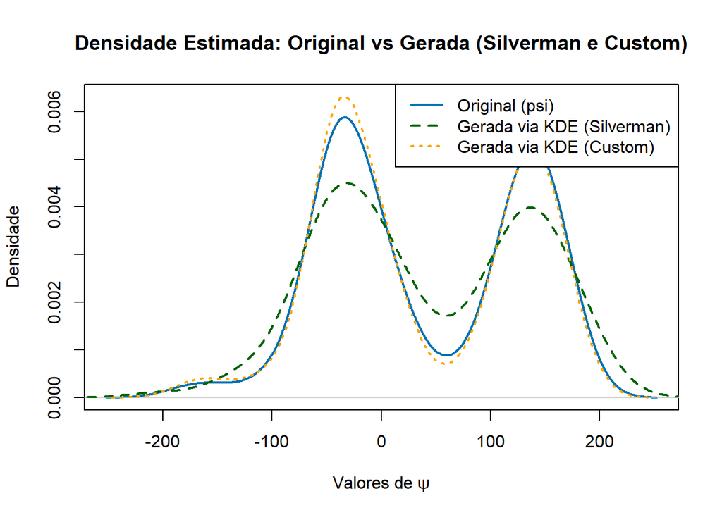

```r
phipsi <- read.csv("http://leg.ufpr.br/~lucambio/Nonparam/phipsi.csv", sep = ",", header = TRUE)
psi <- phipsi$psi

# Função para gerar novas amostras via KDE com kernel Gaussiano
gerar_amostra_kernel <- function(dados, N, h) {
  n <- length(dados)
  nova_amostra <- numeric(N)
  for (i in 1:N) {
    indice <- sample(1:n, 1)  # Escolhe aleatoriamente um ponto da amostra
    nova_amostra[i] <- rnorm(1, mean = dados[indice], sd = h)
  }
  return(nova_amostra)
}

# Calcula a largura de banda via regra de Silverman
h_silverman <- 1.06 * sd(psi) * length(psi)^(-1/5)

# Gera nova amostra com N = 600 usando o bandwidth da regra de Silverman
set.seed(42)  # Reprodutibilidade
N <- 600
nova_amostra_silverman <- gerar_amostra_kernel(psi, N, h_silverman)

# Gera nova amostra com N = 600 usando o bandwidth manual (h_custom)
h_custom <- 0.5  # Exemplo de valor manual para h
nova_amostra_custom <- gerar_amostra_kernel(psi, N, h_custom)

# Estima as densidades
dens_original <- density(psi)
dens_gerada_silverman <- density(nova_amostra_silverman)
dens_gerada_custom <- density(nova_amostra_custom)

# Plota a comparação
plot(dens_original,
     main = "Densidade Estimada: Original vs Gerada (Silverman e Custom)",
     col = "#0072B2", lwd = 2, xlab = "Valores de ψ", ylab = "Densidade", ylim = range(0, max(dens_original$y, dens_gerada_silverman$y, dens_gerada_custom$y)))

# Adiciona as linhas para a densidade gerada com Silverman e customizada
lines(dens_gerada_silverman, col = "darkgreen", lwd = 2, lty = 2)
lines(dens_gerada_custom, col = "orange", lwd = 2, lty = 3)

# Legenda para o gráfico
legend("topright",
       legend = c("Original (psi)", "Gerada via KDE (Silverman)", "Gerada via KDE (Custom)"),
       col = c("#0072B2", "darkgreen", "orange"),
       lwd = 2,
       lty = c(1, 2, 3))
```